# NCAA Division I Basketball Tournament History

```r
AllgamesWC <- read.csv("../Data/History with Conf.csv",header=TRUE, stringsAsFactors = FALSE)
AllgamesWCP <- AllgamesWC
AllgamesWCP$SeD <- AllgamesWC$wSeed-AllgamesWC$LSeed
AllgamesWCP$ScD <- AllgamesWCP$WScore -AllgamesWCP$LScore
AllgamesWCP$Result<-paste(AllgamesWCP$wSeed, AllgamesWCP$LSeed, sep=" over ")
write.csv(AllgamesWCP,"../Data/History with Conf Plus.csv")
AllTeamsLong <- read.csv("../Data/History with Conf Long.csv",header=TRUE, stringsAsFactors = FALSE)
```

### Overview

In 1985, the NCAA expanded their Division I basketball tournament to a 64 team single elimination tournament. Since that time there have been 2117 games (including some play-in games). I have been following the NCAA Division I Basketball tournament for about 15 years. During that time, I have been trying to analyze any possible statistical trends in order to better predict and create a winning bracket. About 40 Million people participate and fill out [70 Million brackets](https://www.quora.com/How-many-people-fill-out-a-March-Madness-bracket-every-year) every year. ESPN’s contest is approaching [20 million brackets](http://www.espn.com/blog/collegebasketballnation/post/_/id/118415/tournament-challenge-new-record-set-for-number-of-brackets-submitted) alone. Even though analyzing the statistics for March Madness is a statistical nightmare, I was able to get a bracket in the 99.9th percentile in the ESPN contest in 2017.

This is the data set of all games that have been played in the NCAA Tournament since 1985 (2117 games).

```r
datatable(AllgamesWCP, extensions = "Responsive",options=list(lengthMenu = c(10,25,68)))
```

|  | Index | Date | Year | Round | Region | wSeed | Winner | WConf | WScore | LSeed | Loser | LConf | LScore | OT | SeD | ScD | Result |
| --- | --- | --- | --- | --- | --- | --- | --- | --- | --- | --- | --- | --- | --- | --- | --- | --- | --- |
| 1 | 1 | 14-Mar-85 | 1985 | 64 | East | 4 | Loyola Chicago | MVC | 59 | 13 | Iona | MAAC | 58 |  | -9 | 1 | 4 over 13 |
| 2 | 2 | 14-Mar-85 | 1985 | 64 | West | 9 | Arkansas | SEC | 63 | 8 | Iowa | B10 | 54 |  | 1 | 9 | 9 over 8 |
| 3 | 3 | 14-Mar-85 | 1985 | 64 | Midwest | 4 | Ohio St. | B10 | 75 | 13 | Iowa St. | B12 | 64 |  | -9 | 11 | 4 over 13 |
| 4 | 4 | 14-Mar-85 | 1985 | 64 | East | 1 | Georgetown | BE | 68 | 16 | Lehigh | Pat | 43 |  | -15 | 25 | 1 over 16 |
| 5 | 5 | 14-Mar-85 | 1985 | 64 | Southeast | 2 | North Carolina | ACC | 76 | 15 | Middle Tennessee | CUSA | 57 |  | -13 | 19 | 2 over 15 |
| 6 | 6 | 14-Mar-85 | 1985 | 64 | Midwest | 1 | Oklahoma | B12 | 96 | 16 | North Carolina A&amp;T | MEAC | 83 |  | -15 | 13 | 1 over 16 |
| 7 | 7 | 14-Mar-85 | 1985 | 64 | Southeast | 3 | Kansas | B12 | 49 | 14 | Ohio | MAC | 38 |  | -11 | 11 | 3 over 14 |
| 8 | 8 | 14-Mar-85 | 1985 | 64 | East | 5 | SMU | Amer | 85 | 12 | Old Dominion | CUSA | 68 |  | -7 | 17 | 5 over 12 |
| 9 | 9 | 14-Mar-85 | 1985 | 64 | Southeast | 7 | Notre Dame | ACC | 79 | 10 | Oregon St. | P12 | 70 |  | -3 | 9 | 7 over 10 |
| 10 | 10 | 14-Mar-85 | 1985 | 64 | Midwest | 5 | Louisiana Tech | CUSA | 78 | 12 | Pittsburgh | ACC | 54 |  | -7 | 24 | 5 over 12 |

[output cut: 2107 more lines]

### Seed History

Some interesting trends have occurred in the past 33 years.

- A number 5 seed has never won a championship even though a 6, 7, and 8 seed have.
- The 10, 11, and 12 seeds have fared much better than the 9 seeds.
- No 16 seed has ever beaten a 1 seed.
- The number 1 seeds have collected the majority of the championships.

```r
AllgamesWCP$Round<-factor(AllgamesWCP$Round, levels=c("Play-in", "64", "32","16","8","4","Champ"))
SH<-table(AllgamesWCP$wSeed,AllgamesWCP$Round)
rownames(SH)<-c("Seed 1","Seed 2","Seed 3","Seed 4","Seed 5","Seed 6","Seed 7","Seed 8","Seed 9","Seed 10","Seed 11","Seed 12","Seed 13","Seed 14","Seed 15","Seed 16")
pander(SH)
```

|  | Play-in | 64 | 32 | 16 | 8 | 4 | Champ |
| --- | --- | --- | --- | --- | --- | --- | --- |
| **Seed 1** | 0 | 132 | 114 | 92 | 54 | 32 | 20 |
| **Seed 2** | 0 | 124 | 83 | 61 | 28 | 13 | 5 |
| **Seed 3** | 0 | 111 | 68 | 32 | 15 | 9 | 4 |
| **Seed 4** | 0 | 106 | 63 | 21 | 13 | 3 | 1 |
| **Seed 5** | 0 | 85 | 43 | 8 | 6 | 3 | 0 |
| **Seed 6** | 0 | 83 | 42 | 14 | 3 | 2 | 1 |
| **Seed 7** | 0 | 81 | 25 | 10 | 3 | 1 | 1 |
| **Seed 8** | 0 | 67 | 13 | 8 | 5 | 3 | 1 |
| **Seed 9** | 0 | 65 | 5 | 2 | 1 | 0 | 0 |
| **Seed 10** | 0 | 51 | 23 | 8 | 1 | 0 | 0 |
| **Seed 11** | 9 | 49 | 20 | 7 | 3 | 0 | 0 |
| **Seed 12** | 3 | 47 | 20 | 1 | 0 | 0 | 0 |
| **Seed 13** | 1 | 26 | 6 | 0 | 0 | 0 | 0 |
| **Seed 14** | 1 | 21 | 2 | 0 | 0 | 0 | 0 |
| **Seed 15** | 0 | 8 | 1 | 0 | 0 | 0 | 0 |
| **Seed 16** | 24 | 0 | 0 | 0 | 0 | 0 | 0 |

### The Big Six

Even though there are 32 basketball conferences, for this tournament there are six conferences (ACC, B10, SEC, B12, BE, P12) that are awarded over half of the tournament invitations.

```r
All64<-subset(AllTeamsLong,Round=="64")
All64big6<-subset(All64,Conf %in% c("ACC","B10","SEC","B12","BE","P12"))
pander(sort(table(All64big6$Conf),decreasing = T),caption = "Number of Appearences by Conference")
```

Number of Appearences by Conference

| ACC | B10 | SEC | B12 | BE | P12 |
| --- | --- | --- | --- | --- | --- |
| 255 | 217 | 187 | 165 | 152 | 152 |

#### Inference

These six conferences are the basketball powerhouses; but is there a difference among them?

$${ H }_{ 0 }:\text{Every conference has the same distribution of seeds.}\\ { H }_{ a }:\text{Not every conference has the same distribution of seeds.}$$

##### Initial Distribution Analysis

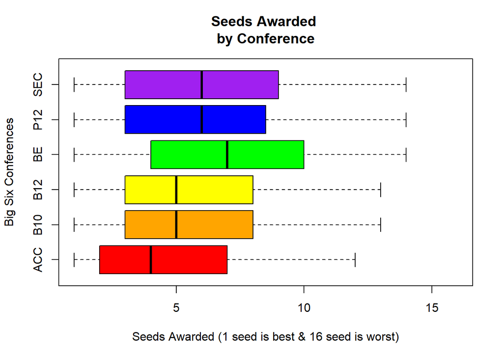

```r
boxplot(Seed ~ Conf, data=All64big6, ylab="Big Six Conferences", xlab="Seeds Awarded (1 seed is best & 16 seed is worst)", main="Seeds Awarded \nby Conference", col=c("red","orange","yellow","green","blue","purple"), horizontal=TRUE, ylim=c(1,16))
```

```r
pander(favstats(Seed ~ Conf, data=All64big6))
```

| Conf | min | Q1 | median | Q3 | max | mean | sd | n | missing |
| --- | --- | --- | --- | --- | --- | --- | --- | --- | --- |
| ACC | 1 | 2 | 4 | 7 | 12 | 4.855 | 3.001 | 255 | 0 |
| B10 | 1 | 3 | 5 | 8 | 13 | 5.53 | 3.005 | 217 | 0 |
| B12 | 1 | 3 | 5 | 8 | 13 | 5.57 | 3.352 | 165 | 0 |
| BE | 1 | 4 | 7 | 10 | 14 | 6.98 | 3.494 | 152 | 0 |
| P12 | 1 | 3 | 6 | 8.25 | 14 | 6.059 | 3.362 | 152 | 0 |
| SEC | 1 | 3 | 6 | 9 | 14 | 6.155 | 3.333 | 187 | 0 |

It appears the the ACC has the advantage of the better seed invitations.

#### Test of Significance

```r
pander(kruskal.test(Seed ~ as.factor(Conf), data=All64big6))
```

Kruskal-Wallis rank sum test: `Seed` by `as.factor(Conf)`

| Test statistic | df | P value |
| --- | --- | --- |
| 42.2 | 5 | 5.375e-08 * * * |

```r
kp<-kruskal.test(Seed ~ as.factor(Conf), data=All64big6)$p.value
kp<-format(kp, scientific=FALSE)
```

With a p-value = 0.00000005374681, we consider it unlikely that these samples are from the same distribution.

### Interpretation

#### Conclusion

With a p-value = 0.00000005374681, we consider it unlikely that these samples are from the same distribution.

- We reject the null hypothesis.
- We conclude that there is sufficient evidence to claim that not all of these samples are from the same distribution.
- The ACC appears to have the best seeds awarded.

#### Follow-up

The ACC and the B10 have the best seed average. Are they significantly different from each other?

$${ H }_{ 0 }:\text{The ACC and B10 have the same distribution of seeds.}\\ { H }_{ a }:\text{The ACC and B10 do not have the same distribution of seeds.}$$

```r
pander(wilcox.test(Seed ~ as.factor(Conf), data=All64big6, subset = Conf %in% c("ACC", "B10")))
```

Wilcoxon rank sum test with continuity correction: `Seed` by `as.factor(Conf)`

| Test statistic | P value | Alternative hypothesis |
| --- | --- | --- |
| 23928 | 0.01094 * | two.sided |

```r
wp<-wilcox.test(Seed ~ as.factor(Conf), data=All64big6, subset = Conf %in% c("ACC", "B10"))$p.value
```

With a p-value = 0.0109367, we consider it unlikely that the ACC and the B10 are from the same distribution.

- We reject the null hypothesis.
- We conclude that there is sufficient evidence to claim that the ACC and B10 do not have the same distribution of seeds.
- The ACC appears to have the best seeds awarded.